# Twitter Sentiment Analysis

### Daily Summary

> - The number of positive and negative tweets are almost the same. Neutral tweets are however higher across the timeline
> - This can be confirmed by the two graphs shown below

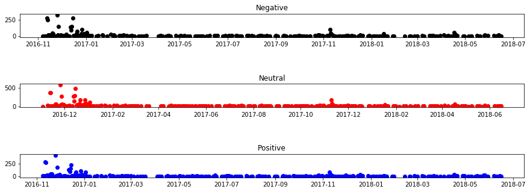

```python
#plt.figure(figsize=(20,50))
#plt.plot(figsize=(50,40))
fig, axes = plt.subplots(nrows=3,figsize=(15,5))
fig.subplots_adjust(hspace=2)
colors = ('k', 'r', 'b')
i=0

for ax, color in zip(axes, colors):
    if i==0:
        data=neg
        titlex='Negative'
    if i==1:
        data=neu
        titlex='Neutral'
    if i==2:
        data=pos
        titlex='Positive'
    i=i+1
    ax.plot(data, marker='o', linestyle='none', color=color)
    ax.set_title(titlex)
plt.show()
```

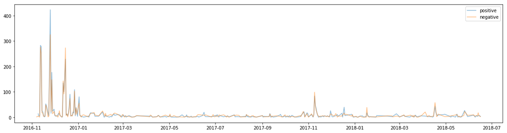

```python
plt.figure(figsize=(20,5))
#plt.plot(figsize=(50,40))
plt.plot(pos,alpha=0.5,label='positive')
plt.plot(neg,alpha=0.5,label='negative')

#plt.hist(neu,alpha=0.5,label='neutral')
plt.legend(loc='upper right')
plt.show()
```

```python
df5=df4
df5 = df5.set_index(pd.DatetimeIndex(df5['date']))
df5neg = df5[df5['sentiment_type']=='NEGATIVE']
df5neu = df5[df5['sentiment_type']=='NEUTRAL']
df5pos = df5[df5['sentiment_type']=='POSITIVE']

df5neg = df5neg.resample("M", how='sum')
df5neu = df5neu.resample("M", how='sum')
df5pos = df5pos.resample("M", how='sum')
```

> - **The number of sentiment counts across all the months remain the same**

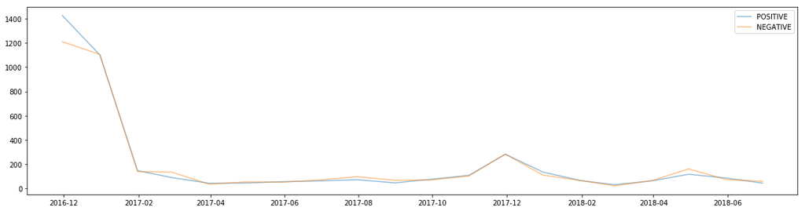

```python
plt.figure(figsize=(20,5))
plt.plot(df5pos['sent_count'],alpha=0.5,label='POSITIVE')
plt.plot(df5neg['sent_count'],alpha=0.5,label='NEGATIVE')
#plt.plot(df5neu['sent_count'],alpha=0.5,label='NEUTRAL')
plt.legend(loc='upper right')
plt.show()
```

> - **Sentiment score majorly remains similar, however at most times negative score edges over the positive scores**

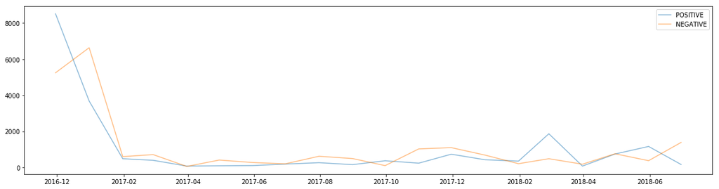

```python
plt.figure(figsize=(20,5))
plt.plot(df5pos['calc_score'],alpha=0.5,label='POSITIVE')
plt.plot(df5neg['calc_score']*-1,alpha=0.5,label='NEGATIVE')
#plt.plot(df5neu['calc_score'],alpha=0.5,label='NEUTRAL')
plt.legend(loc='upper right')
plt.show()
```

## WordCloud on Training Data

```python
df_bow= df3[['text_lem','sentiment_type']]
```

> Credit: https://www.kaggle.com/ngyptr/python-nltk-sentiment-analysis/notebook
> - **Below code is to create a dataframe of cleaned tweet content, following techniques are applied to clean the content**
>   - **Remove any tweet references in the news articles (hash tags, handles, Retweets)**
> - **Created a training and test set of the data, for creating a wordcloud**
>   - **Training set was created to see if there are any unwanted stop words that were included.**
>   - **It was during the training set, we observed that java script code was present in the text content and we had to remove the same**
> - **Below pics show the positive & negative sentiment wordclouds**

```python
import numpy as np # linear algebra
import pandas as pd # data processing, CSV file I/O (e.g. pd.read_csv)
from sklearn.model_selection import train_test_split # function for splitting data to train and test sets
from wordcloud import WordCloud,STOPWORDS
import matplotlib.pyplot as plt
%matplotlib inline
from subprocess import check_output
```

```
3277
Positive words
```

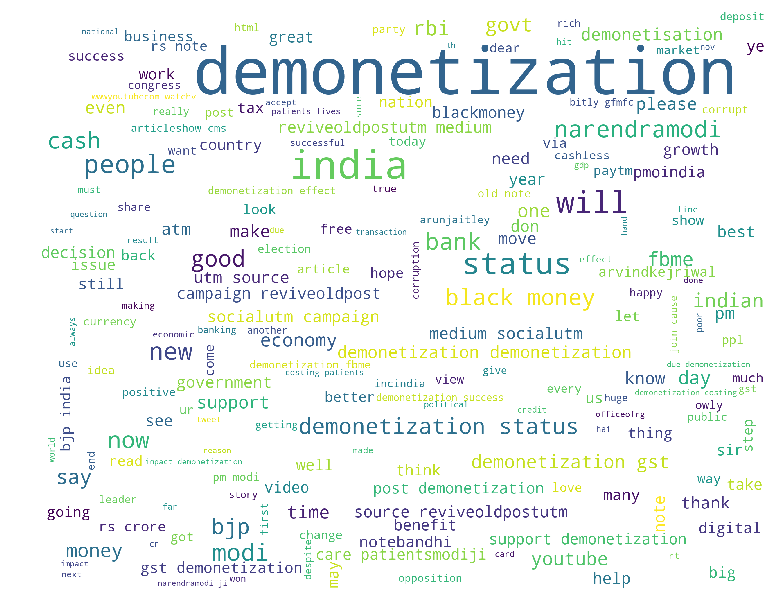

```
Negative words
```

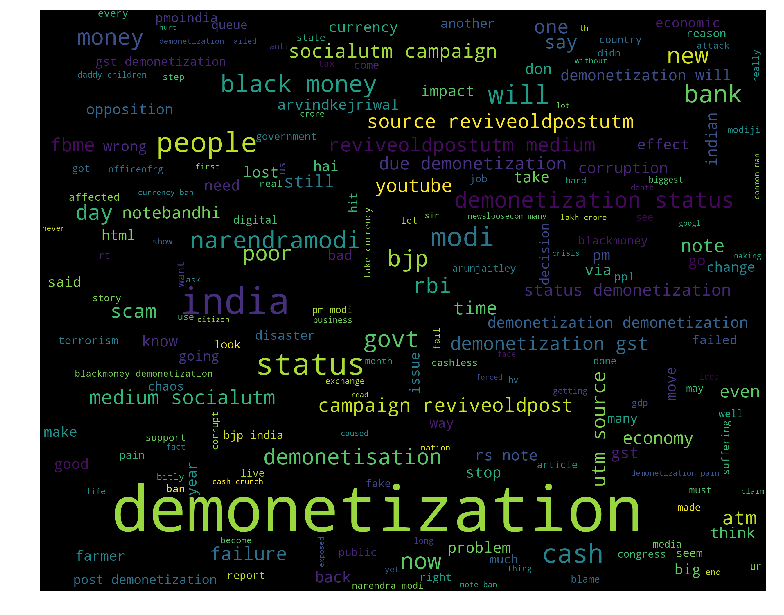

```python
# Splitting the dataset into train and test set
train, test = train_test_split(df_bow,test_size = 0.2)
# Removing neutral sentiments
train = train[train.sentiment_type != "Neutral"]
#print('len of train',len(train[ train['sentiment_type'] == 'Positive']))
train_pos = train[ train['sentiment_type'] == 'POSITIVE']
train_pos = train_pos['text_lem']
print(len(train_pos))
train_neg = train[ train['sentiment_type'] == 'NEGATIVE']
train_neg = train_neg['text_lem']
def wordcloud_draw(data, color = 'black'):
    words = ' '.join(data)
    cleaned_word = " ".join([word for word in words.split()
                            if 'http' not in word
                                and not word.startswith('@')
                                and not word.startswith('#')
                                and word != 'RT'
                            ])
    wordcloud = WordCloud(stopwords=STOPWORDS,
                      background_color=color,
                      width=2500,
                      height=2000
                     ).generate(cleaned_word)
    plt.figure(1,figsize=(13, 13))
    plt.imshow(wordcloud)
    plt.axis('off')
    plt.show()

print("Positive words")
wordcloud_draw(train_pos,'white')
print("Negative words")
wordcloud_draw(train_neg)
```

```python
from nltk.corpus import stopwords
tweets = []
stopwords_set = set(stopwords.words("english"))

for index, row in df_bow.iterrows():
    words_filtered = [e.lower() for e in row.text_lem.split() if len(e) >= 3]
    words_cleaned = [word for word in words_filtered
        if 'http' not in word
        and not word.startswith('@')
        and not word.startswith('#')
        and word != 'RT']
    words_without_stopwords = [word for word in words_cleaned if not word in stopwords_set]
    tweets.append((words_without_stopwords,row.sentiment_type))


test_pos = test[ test['sentiment_type'] == 'Positive']
test_pos = test_pos['text_lem']
test_neg = test[ test['sentiment_type'] == 'Negative']
test_neg = test_neg['text_lem']
```

```python
# Extracting word features
def get_words_in_tweets(tweets):
    all = []
    for (words, sentiment) in tweets:
        all.extend(words)
    return all

def get_word_features(wordlist):
    wordlist = nltk.FreqDist(wordlist)
    features = wordlist.keys()
    return features
w_features = get_word_features(get_words_in_tweets(tweets))

def extract_features(document):
    document_words = set(document)
    features = {}
    for word in w_features:
        features['contains(%s)' % word] = (word in document_words)
    return features
```

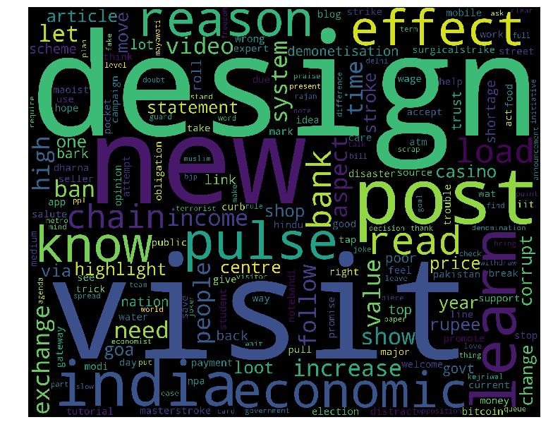

```python
wordcloud_draw(w_features)
```